# Assignment 2

STATS 220 Semester One 2022

Daniel Woo

31/03/2022

## Introduction

For this report, I decided to explore what the most common devices used to listen to music were, the most popular genres and how often people update their music libraries. These were shown using stacked bar graphs, colour-coded using the most common devices to observe the individual results and their combined results. Relationships between variables were also explored. I wanted to see if there were any trends between the hours of music listened to per day and the frequency of music library updates. The relationship between the device type and number of hours listened to per day was also explored. Both of these relationships were visualised using side-by-side boxplots. All data used was collected through a Google Form which was converted to a CSV File.

## Links to form and data

Link to the Google Form: https://docs.google.com/forms/d/1ChJBYHdQ4o8tg4r5vFskwdw-O7rqhAIMIXLsPxQazRQ/edit

URL for the CSV File: https://docs.google.com/spreadsheets/d/e/2PACX-1vRlzz9oN35sraPStWz-rmNIeJhREDt3vEMNAShCPm3WH3ucKNPbtG2luKyF_qSaqFJ011ItXDlFgrVo/pub?gid=1587540473&single=true&output=csv

## Analytics

The table below shows the first five rows from the data I collected from people who filled out my Google Form.

| music_hours | device_hours | songs_library | device_common | library_update | fav_genre | types_genre | music_sources |
| --- | --- | --- | --- | --- | --- | --- | --- |
| 1 | 8 | 40 | Phone | Once a month | Pop | Hiphop / Rap, Pop, R&B, Lofi | Spotify, YouTube |
| 3 | 8 | 120 | PC / Laptop | Once a year | Lofi | Hiphop / Rap, Pop, R&B, Jazz, Lofi, Instrumental, Religious | Spotify, YouTube |
| 1 | 12 | 800 | Phone | Once every 6 months | R&B | Hiphop / Rap, Pop, R&B, Jazz, Religious | Spotify, YouTube, Apple Music |
| 2 | 2 | 200 | Phone | Once every 3 months | Jazz | Religious | Spotify |
| 2 | 10 | 1000 | PC / Laptop | Once every 3 months | R&B | Hiphop / Rap, Pop, R&B, Lofi | Spotify, YouTube |

In total, 29 students completed my form (one person’s answers were removed as it was not a sensible answer; ie. listening to music for more than 24 hours a day).

First, I wanted to observe which device was most commonly used to listen to music.

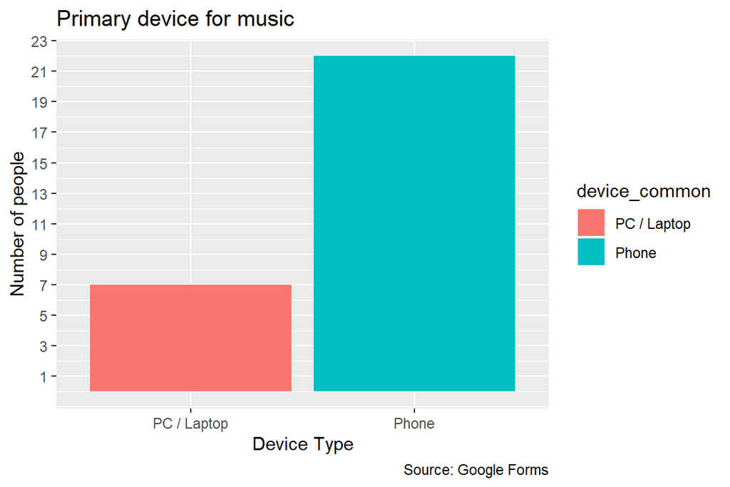

The most common device used to listen to music seemed to be Phone, with 22 people choosing this option. This was followed by PC / Laptop with 7 people choosing this option. These were the two primary devices used to listen to music.

Next, I was curious to find which genre of music was the most popular within my sample of data. I wanted to see if the results were similar for phone users and PC / Laptop users.

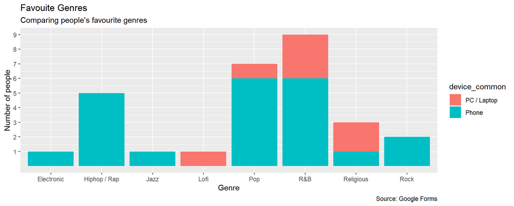

The most popular genre was R&B, with 9 people choosing this option. The least popular was a three-way tie between Electronic, Jazz, Lofi with only a single person each choosing these options. It seems that PC / Laptop users preferred to listen to lofi, pop, R&B and religious music. A future study observing the affects of studying while listening to music, device choice and these genre choices could be explored as the favoured genres of PC / Laptop users are typically less distracting or ‘intense’ than options favoured by phone users.

I also wanted to see how often people updated their music libraries and playlists.

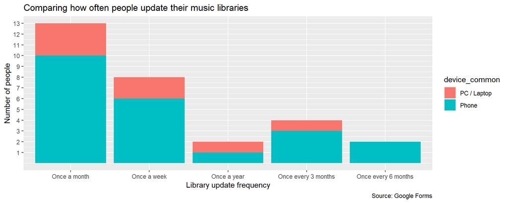

The most common library/playlist update frequency was Once a month. This was true for both PC / Laptop and Phone users as seen in the graph.

I was also interested in observing the relationships between variables to see if there are any correlations between certain variables.

The first relationship I wanted to explore is the number of hours of music listened to per day and the frequency of updating libraries/playlists. This was observed using side-by-side boxplots.

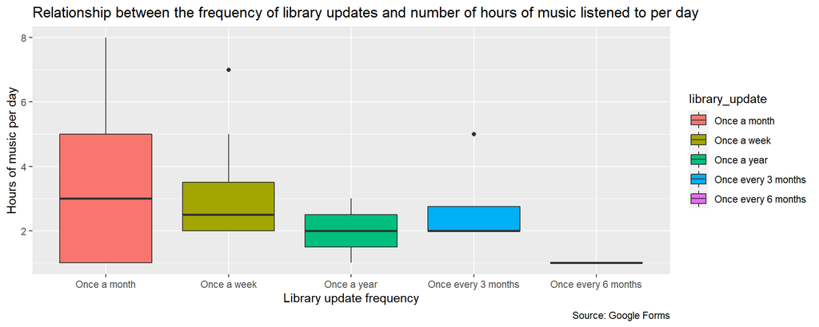

The boxplot of Once a month had the highest median of the five, approximately 3 hours, and also had the highest maximum value. It also had the lowest lower quartile value, along with Once every 6 months. However, it also had the highest upper quartile value. A future study with a larger sample size may change these results.

The second relationship I wanted to explore is the number of hours of music listened to per day and the primary device used to listen to music. This was also observed using side-by-side boxplots.

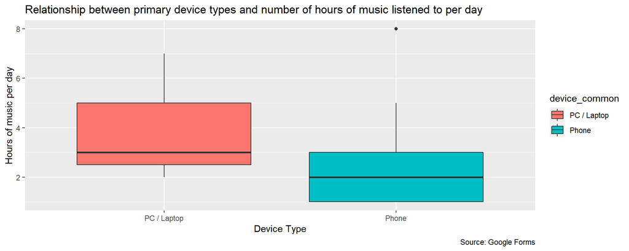

## Learning reflection

Module 2 Creating dynamic reporting systems had several key ideas that helped me with my understanding. Plotting data is an idea I thought was very important as I am aiming to work in data analysis. Being able to visualise data using code is the very start of analysis. Through graphs, trends can be observed and information such as maximum and minimum values, medians and means can be collected. The options for inline code we learnt such as nrow() also helps us collect data such as the number of rows in a table, making it easier to get this information without manually searching and entering this value. If the table is expanded, the code updates the value, making it more automatic and thus reducing workload.

Using the techniques learnt from Assignment 1, I changed the look of this Rmarkdown file using CSS. I changed the fonts and the colours of the headings and body paragraphs. R chunks were used to develop R code and there were changes the knitr::opts_chunk$set() settings to produce the correct outputs I wanted. Comments were also used to make sure the code is easier to understand.

I am looking forward to exploring more parts of data technology related to this assignment such as plotting graphs to show relationships between several variables (numeric-numeric, numeric-categorical, categorical-categorical) and finding key values within these plots. I struggled with using inline code to find values such as medians when faced with categorical plots so I think it would be very beneficial to learn more advanced functions and methods that can help me with extracting data from plots and tables. Also mentioned in the previous assignment, I would like to continue to explore interactive and animated plots. A teaching assistant mentioned https://r-graph-gallery.com/, a website that focuses on tidyverse and ggplot2 to show different plots, including interactive and animated plots. They have courses that aid in developing skills which would be a good start for the direction I want to go in.